# Tech 2, Descriptives

### Data

The datasets in thie file were worked up in the project file [01_CRI_Data_Prep.Rm](https://github.com/nbreznau/CRI/blob/master/01_CRI_Data_Prep.Rmd). In the CRI.Rproj. Project and data available via GitHub.

1. *cri.csv* = model-level data, numerical values
2. *cri_team.csv* = team-level data

### Descriptives

There were 16 teams that came to more than one conclusion. For example, finding support of the hypothesis for immigration stock models, but finding rejection of the hypothesis for immigration flow models. Therefore, we have 89 observations (‘results’) in the team-level data that derive from 72 teams. We also have the conclusion from the study by Brady and Finnigan ([2014](https://doi.org/10.1177/000312240607100306)) that provides an example of a state of the art study for testing this hypothesis to use as an additional ‘data point’ in additional analyses.

#### Table 1. Team-Results-Level Descriptive Statistics

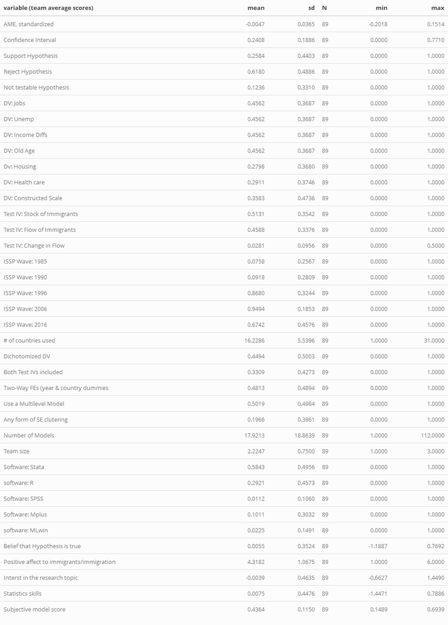

```r
knitr::include_graphics("results/Table1.png")
```